# RJ Metrics

Jacob Rozran

March 21, 2016

# Introduction

In this exercise, I’ve been asked to “take a look at the [Bike Theft data on OpenDataPhilly](https://www.opendataphilly.org/dataset/bicycle-thefts). What insights can you draw about patterns of bike theft in Philadelphia? We encourage you to use open source tools, such as Python or R to analyze the data set. Please provide your script and results to support your findings.”

# Getting Started

At the link above, I found two datasets. One that spans from January 1, 2010 through September 16, 2013 and another that spans from September 15, 2014 through February 8, 2015. I downloaded them both as CSV files and read them into R.

```r
library(ggplot2)        # WILL BE USED TO DISPLAY SOME DATA VISUALLY
library(ggmap)          # WILL BE USED TO GET MAPS OF PHILADELPHIA
library(plyr)           # WILL BE USED TO HELP SUMMARIZE THE DATA

early_data <- read.csv("Bicycle_Thefts.csv")
later_data <- read.csv("Bicycle_Thefts_9_15_2014_-_2_8_2015.csv")
```

## First Looks at the Data

```r
## RENAME THINGS TO MAKE THEM EASIER TO DEAL WITH AND/OR MATCH ONE ANOTHER
names(early_data) <- c("DC_Number", "DC_Key", "Location", "Theft_Date",
                       "Theft_Year", "District", "Stolen_Value", "Theft_Hour",
                       "UCR", "lat", "lon", "Location_1")
names(later_data) <- c("FID", "DC_Number", "DC_Key", "Location", "Theft_Date",
                       "Theft_Year", "District", "Stolen_Value", "Theft_Hour",
                       "UCR", "Location_1", "Y", "GlobalID", "x2", "y2")

## CHANGE THE DATE FIELD INTO A DATE VARIABLE IN THE R CONTEXT
early_data$Theft_Date <- as.POSIXct(strptime(as.character(early_data$Theft_Date),
                                             format = "%m/%d/%Y %I:%M:%S %p"))
later_data$Theft_Date <- as.POSIXct(strptime(as.character(later_data$Theft_Date),
                                             format = "%m/%d/%Y %I:%M:%S %p"))

## MAKE LATITUDE AND LONGITUDE FIELDS IN THE later_data
later_latlong <- later_data$Location_1
later_latlong <- gsub(pattern = "\\(", replacement = "", x = later_latlong)
later_latlong <- gsub(pattern = "\\)", replacement = "", x = later_latlong)
later_latlong <- strsplit(later_latlong, ", ")
later_latlong <- ldply(later_latlong, rbind)
names(later_latlong) <- c("lon", "lat")
later_latlong$lon <- as.numeric(as.character(later_latlong$lon))
later_latlong$lat <- as.numeric(as.character(later_latlong$lat))

## ADD THE LATITUDE AND LONGITUDE TO THE later_data DATAFRAME
later_data <- cbind(later_data, later_latlong)
```

With those steps completed, I am now able to combine the two data frames into one.

```r
combined_data <- rbind(early_data, later_data[, c(2:10, 17, 16, 11)])
```

# Exploring the Data

## Stolen Bike Values

Now that I have a single dataset, let’s see what the data looks like. I start with the values of the bikes stolen. Being a cyclist myself, I know these things aren’t cheap. What kind of bikes are the miscreants of Philadelphia stealing?

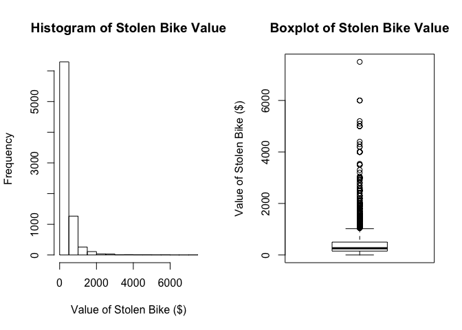

```r
par(mfrow = c(1,2))
hist(combined_data$Stolen_Value, xlab = "Value of Stolen Bike ($)",
     main = "Histogram of Stolen Bike Value")
boxplot(combined_data$Stolen_Value, ylab = "Value of Stolen Bike ($)",
        main = "Boxplot of Stolen Bike Value")
```

```r
quantile(combined_data$Stolen_Value, c(0.1, 0.25, 0.5, 0.75, 0.9))
```

```
## 10% 25% 50% 75% 90%
##  90 150 260 500 804
```

Looking above, you can see that there are definitely some expensive bikes stolen. The most expensive bike was $7500. I really hope that that bike wasn’t just left outside somewhere… The first thing that becomes obvious here is that 75% of bikes are valued at $500 and below; not a small chunk of change, but small potatoes compared to the higher end bikes out there.

## Uniform Crime Report Codes

Now, there are three Uniform Crime Report (UCR) codes present in the data. After a substantial amount of Googling, a message to an acquaintance of mine at Socrata (the company is responsible for posting the data for OpenDataPhilly), and a few tweets to the CDO of the city, Tim Wisniewski, I was unable to say definitively what the difference is between these codes… I was only able to find information suggesting the 6xx codes are larceny (pretty obvious). So, I tried to get the data to tell me.

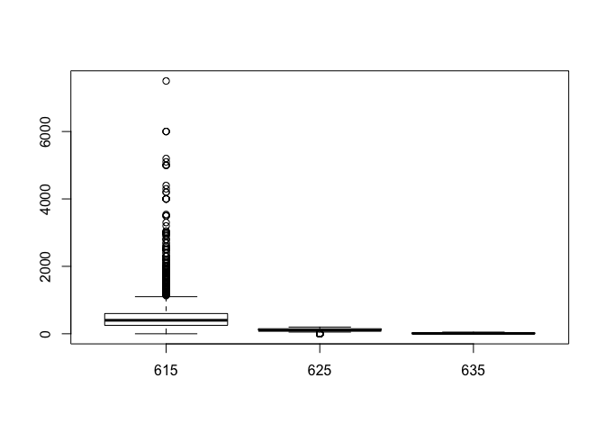

```r
par(mfrow = c(1,1))
boxplot(combined_data$Stolen_Value ~ combined_data$UCR)
```

```r
count_by_UCR <- ddply(combined_data, .(UCR), summarize, count = length(UCR))
print(count_by_UCR)
```

```
##   UCR count
## 1 615  5467
## 2 625  2377
## 3 635   183
```

About two-thirds of the data is labeled as a UCR of 615. Those bikes stolen under that pretense span the range of Stolen Value. 625 encompasses a majority of that final one-third, but the bikes are much more modestly valued. 635 is only a small percentage of the overall count and accounts for even more modestly valued bikes yet.

## Timing of the Theft

Now that we know what the bad-guys stole and, to an extent, how, when did they steal the bikes?

In looking at the hour of the day, the most bikes are reported stolen at 17:00 (5:00 PM). This makes sense to me; you leave your bike while you are working and come out to find it is gone.

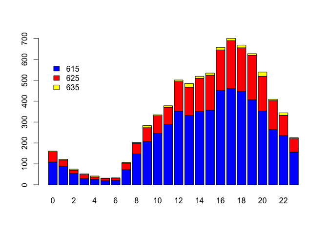

```r
count_by_hour <- ddply(combined_data, .(Theft_Hour), summarize,
                       count615 = length(Theft_Hour[UCR == 615]),
                       count625 = length(Theft_Hour[UCR == 625]),
                       count635 = length(Theft_Hour[UCR == 635]))
rownames(count_by_hour) <- count_by_hour$Theft_Hour
count_by_hour$Theft_Hour <- NULL
count_by_hour <- t(count_by_hour)
rownames(count_by_hour) <- c("615", "625", "635")
barplot(count_by_hour, col = c("blue", "red", "yellow"))
legend(0, 600, rownames(count_by_hour), fill = c("blue", "red", "yellow"),
       bty = "n")
```

I was not expecting to see that the day of the week when most bikes were reported stolen was Monday. Thinking more about it - if you are gone all weekend or only using your bike to commute to work, it’s entirely reasonable that Monday would have the most reports.

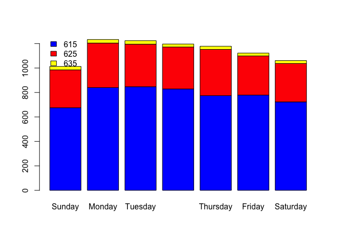

```r
combined_data$dow <- weekdays(combined_data$Theft_Date)

count_by_weekday <- ddply(combined_data, .(dow), summarize,
                          count615 = length(dow[UCR == 615]),
                          count625 = length(dow[UCR == 625]),
                          count635 = length(dow[UCR == 635]))
count_by_weekday$num <- c(6, 2, 7, 1, 5, 3, 4)
count_by_weekday <- count_by_weekday[order(count_by_weekday$num), ]
count_by_weekday$num <- NULL
rownames(count_by_weekday) <- count_by_weekday$dow
count_by_weekday$dow <- NULL
count_by_weekday <- t(count_by_weekday)
rownames(count_by_weekday) <- c("615", "625", "635")
barplot(count_by_weekday, col = c("blue", "red", "yellow"))
legend(0, 1275, rownames(count_by_weekday), fill = c("blue", "red", "yellow"),
       bty = "n")
```

Not surprising at all is that most bikes are stolen in the summer. People ride more in the summer; only crazy people like me ride a bike in the winter.

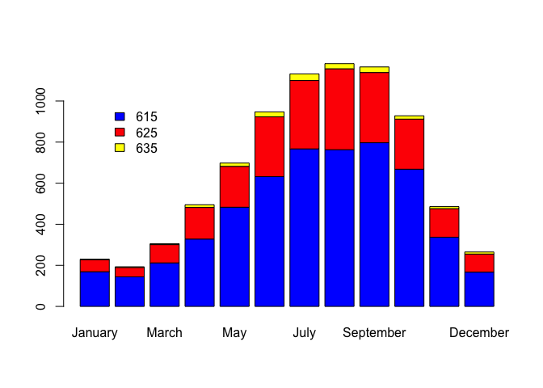

```r
combined_data$month <- months(combined_data$Theft_Date)

count_by_month <- ddply(combined_data, .(month), summarize,
                        count615 = length(month[UCR == 615]),
                        count625 = length(month[UCR == 625]),
                        count635 = length(month[UCR == 635]))
count_by_month$num <- c(4, 8, 12, 2, 1, 7, 6, 3, 5, 11, 10, 9)
count_by_month <- count_by_month[order(count_by_month$num), ]
count_by_month$num <- NULL
rownames(count_by_month) <- count_by_month$month
count_by_month$month <- NULL
count_by_month <- t(count_by_month)
rownames(count_by_month) <- c("615", "625", "635")
barplot(count_by_month, col = c("blue", "red", "yellow"))
legend(1, 1000, rownames(count_by_month), fill = c("blue", "red", "yellow"),
       bty = "n")
```

## Location of the Theft

The last part of this data I want to investigate is where the thefts are occurring. You can see below that there is a very hot spot at center city with two other warm spots at Temple and University City.

[figure not shown]

```r
phil2 <- get_map(location = "Philadelphia", maptype = "roadmap", zoom = 12)
map2 <- ggmap(phil2, extent = "device") +
        geom_density2d(data = early_data, aes(x = lon, y = lat)) +
        stat_density2d(data = early_data, aes(fill = ..level.., alpha = ..level..),
                       size = 0.01, geom = "polygon") +
        scale_fill_gradient(low = "green", high = "red", guide = FALSE) +
        scale_alpha(range = c(0, 0.3), guide = FALSE)

phil1 <- get_map(location = "Philadelphia", maptype = "roadmap", zoom = 13)
map1 <- ggmap(phil1, extent = "device") +
        geom_density2d(data = early_data, aes(x = lon, y = lat)) +
        stat_density2d(data = early_data, aes(fill = ..level.., alpha = ..level..),
                       size = 0.01, geom = "polygon") +
        scale_fill_gradient(low = "green", high = "red", guide = FALSE) +
        scale_alpha(range = c(0, 0.3), guide = FALSE)

map2
```

[figure not shown]

```r
map1
```

# Summary

To close, I want to summarize what trends I’ve observed here. I was able to show that most bikes stolen in Philadelphia are of modest value. They are most probable time of the day to report a stolen bike is 5:00 PM and the most probable day is Monday. The summer sees many more bikes stolen than the other seasons. Center City is a hot-spot for bike theft with the urban campuses of Temple, Penn, and Drexel being other areas of high bike theft activity.